# OrdinalEncoder

**class*sklearn.preprocessing.OrdinalEncoder(*, *categories='auto'*, *dtype=<class 'numpy.float64'>*, *handle_unknown='error'*, *unknown_value=None*, *encoded_missing_value=nan*, *min_frequency=None*, *max_categories=None*)[[source]](https://github.com/scikit-learn/scikit-learn/blob/99bf3d8e4/sklearn/preprocessing/_encoders.py#L1254)**

Encode categorical features as an integer array.

The input to this transformer should be an array-like of integers or strings, denoting the values taken on by categorical (discrete) features. The features are converted to ordinal integers. This results in a single column of integers (0 to n_categories - 1) per feature.

Read more in the User Guide. For a comparison of different encoders, refer to: Comparing Target Encoder with Other Encoders.

Added in version 0.20.

**Parameters:**

**categories**‘auto’ or a list of array-like, default=’auto’**

Categories (unique values) per feature:

- ‘auto’ : Determine categories automatically from the training data.
- list : `categories[i]` holds the categories expected in the ith column. The passed categories should not mix strings and numeric values, and should be sorted in case of numeric values.

The used categories can be found in the `categories_` attribute.

**dtype**number type, default=np.float64**

Desired dtype of output.

**handle_unknown**{‘error’, ‘use_encoded_value’}, default=’error’**

When set to ‘error’ an error will be raised in case an unknown categorical feature is present during transform. When set to ‘use_encoded_value’, the encoded value of unknown categories will be set to the value given for the parameter `unknown_value`. In `inverse_transform`, an unknown category will be denoted as None.

Added in version 0.24.

**unknown_value**int or np.nan, default=None**

When the parameter handle_unknown is set to ‘use_encoded_value’, this parameter is required and will set the encoded value of unknown categories. It has to be distinct from the values used to encode any of the categories in `fit`. If set to np.nan, the `dtype` parameter must be a float dtype.

Added in version 0.24.

**encoded_missing_value**int or np.nan, default=np.nan**

Encoded value of missing categories. If set to `np.nan`, then the `dtype` parameter must be a float dtype.

Added in version 1.1.

**min_frequency**int or float, default=None**

Specifies the minimum frequency below which a category will be considered infrequent.

- If `int`, categories with a smaller cardinality will be considered infrequent.
- If `float`, categories with a smaller cardinality than `min_frequency * n_samples` will be considered infrequent.

Added in version 1.3: Read more in the User Guide.

**max_categories**int, default=None**

Specifies an upper limit to the number of output categories for each input feature when considering infrequent categories. If there are infrequent categories, `max_categories` includes the category representing the infrequent categories along with the frequent categories. If `None`, there is no limit to the number of output features.

`max_categories` do **not** take into account missing or unknown categories. Setting `unknown_value` or `encoded_missing_value` to an integer will increase the number of unique integer codes by one each. This can result in up to `max_categories + 2` integer codes.

Added in version 1.3: Read more in the User Guide.

**Attributes:**

**categories_**list of arrays**

The categories of each feature determined during `fit` (in order of the features in X and corresponding with the output of `transform`). This does not include categories that weren’t seen during `fit`.

**n_features_in_**int**

Number of features seen during fit.

Added in version 1.0.

**feature_names_in_**ndarray of shape (`n_features_in_`,)**

Names of features seen during fit. Defined only when `X` has feature names that are all strings.

Added in version 1.0.

**`infrequent_categories_`list of ndarray**

Infrequent categories for each feature.

See also

**`OneHotEncoder`**

Performs a one-hot encoding of categorical features. This encoding is suitable for low to medium cardinality categorical variables, both in supervised and unsupervised settings.

**`TargetEncoder`**

Encodes categorical features using supervised signal in a classification or regression pipeline. This encoding is typically suitable for high cardinality categorical variables.

**`LabelEncoder`**

Encodes target labels with values between 0 and `n_classes-1`.

#### Notes

With a high proportion of `nan` values, inferring categories becomes slow with Python versions before 3.10. The handling of `nan` values was improved from Python 3.10 onwards, (c.f. [bpo-43475](https://github.com/python/cpython/issues/87641)).

#### Examples

Given a dataset with two features, we let the encoder find the unique values per feature and transform the data to an ordinal encoding.

```
>>> from sklearn.preprocessing import OrdinalEncoder
>>> enc = OrdinalEncoder()
>>> X = [['Male', 1], ['Female', 3], ['Female', 2]]
>>> enc.fit(X)
OrdinalEncoder()
>>> enc.categories_
[array(['Female', 'Male'], dtype=object), array([1, 2, 3], dtype=object)]
>>> enc.transform([['Female', 3], ['Male', 1]])
array([[0., 2.],
       [1., 0.]])
```

```
>>> enc.inverse_transform([[1, 0], [0, 1]])
array([['Male', 1],
       ['Female', 2]], dtype=object)
```

By default, `OrdinalEncoder` is lenient towards missing values by propagating them.

```
>>> import numpy as np
>>> X = [['Male', 1], ['Female', 3], ['Female', np.nan]]
>>> enc.fit_transform(X)
array([[ 1.,  0.],
       [ 0.,  1.],
       [ 0., nan]])
```

You can use the parameter `encoded_missing_value` to encode missing values.

```
>>> enc.set_params(encoded_missing_value=-1).fit_transform(X)
array([[ 1.,  0.],
       [ 0.,  1.],
       [ 0., -1.]])
```

Infrequent categories are enabled by setting `max_categories` or `min_frequency`. In the following example, “a” and “d” are considered infrequent and grouped together into a single category, “b” and “c” are their own categories, unknown values are encoded as 3 and missing values are encoded as 4.

```
>>> X_train = np.array(
...     [["a"] * 5 + ["b"] * 20 + ["c"] * 10 + ["d"] * 3 + [np.nan]],
...     dtype=object).T
>>> enc = OrdinalEncoder(
...     handle_unknown="use_encoded_value", unknown_value=3,
...     max_categories=3, encoded_missing_value=4)
>>> _ = enc.fit(X_train)
>>> X_test = np.array([["a"], ["b"], ["c"], ["d"], ["e"], [np.nan]], dtype=object)
>>> enc.transform(X_test)
array([[2.],
       [0.],
       [1.],
       [2.],
       [3.],
       [4.]])
```

**fit(*X*, *y=None*)[[source]](https://github.com/scikit-learn/scikit-learn/blob/99bf3d8e4/sklearn/preprocessing/_encoders.py#L1473)**

Fit the OrdinalEncoder to X.

**Parameters:**

**X**array-like of shape (n_samples, n_features)**

The data to determine the categories of each feature.

**y**None**

Ignored. This parameter exists only for compatibility with `Pipeline`.

**Returns:**

**self**object**

Fitted encoder.

**fit_transform(*X*, *y=None*, **fit_params)[[source]](https://github.com/scikit-learn/scikit-learn/blob/99bf3d8e4/sklearn/base.py#L863)**

Fit to data, then transform it.

Fits transformer to `X` and `y` with optional parameters `fit_params` and returns a transformed version of `X`.

**Parameters:**

**X**array-like of shape (n_samples, n_features)**

Input samples.

**y**array-like of shape (n_samples,) or (n_samples, n_outputs), default=None**

Target values (None for unsupervised transformations).

**fit_paramsdict**

Additional fit parameters.

**Returns:**

**X_new**ndarray array of shape (n_samples, n_features_new)**

Transformed array.

**get_feature_names_out(*input_features=None*)[[source]](https://github.com/scikit-learn/scikit-learn/blob/99bf3d8e4/sklearn/base.py#L943)**

Get output feature names for transformation.

**Parameters:**

**input_features**array-like of str or None, default=None**

Input features.

- If `input_features` is `None`, then `feature_names_in_` is used as feature names in. If `feature_names_in_` is not defined, then the following input feature names are generated: `["x0", "x1", ..., "x(n_features_in_ - 1)"]`.
- If `input_features` is an array-like, then `input_features` must match `feature_names_in_` if `feature_names_in_` is defined.

**Returns:**

**feature_names_out**ndarray of str objects**

Same as input features.

**get_metadata_routing()[[source]](https://github.com/scikit-learn/scikit-learn/blob/99bf3d8e4/sklearn/utils/_metadata_requests.py#L1497)**

Get metadata routing of this object.

Please check [User Guide](https://scikit-learn.org/1.6/metadata_routing.html#metadata-routing) on how the routing mechanism works.

**Returns:**

**routing**MetadataRequest**

A `MetadataRequest` encapsulating routing information.

**get_params(*deep=True*)[[source]](https://github.com/scikit-learn/scikit-learn/blob/99bf3d8e4/sklearn/base.py#L231)**

Get parameters for this estimator.

**Parameters:**

**deep**bool, default=True**

If True, will return the parameters for this estimator and contained subobjects that are estimators.

**Returns:**

**params**dict**

Parameter names mapped to their values.

**property*infrequent_categories_**

Infrequent categories for each feature.

**inverse_transform(*X*)[[source]](https://github.com/scikit-learn/scikit-learn/blob/99bf3d8e4/sklearn/preprocessing/_encoders.py#L1614)**

Convert the data back to the original representation.

**Parameters:**

**X**array-like of shape (n_samples, n_encoded_features)**

The transformed data.

**Returns:**

**X_tr**ndarray of shape (n_samples, n_features)**

Inverse transformed array.

**set_output(*, *transform=None*)[[source]](https://github.com/scikit-learn/scikit-learn/blob/99bf3d8e4/sklearn/utils/_set_output.py#L392)**

Set output container.

See Introducing the set_output API for an example on how to use the API.

**Parameters:**

**transform**{“default”, “pandas”, “polars”}, default=None**

Configure output of `transform` and `fit_transform`.

- `"default"`: Default output format of a transformer
- `"pandas"`: DataFrame output
- `"polars"`: Polars output
- `None`: Transform configuration is unchanged

Added in version 1.4: `"polars"` option was added.

**Returns:**

**self**estimator instance**

Estimator instance.

**set_params(**params)[[source]](https://github.com/scikit-learn/scikit-learn/blob/99bf3d8e4/sklearn/base.py#L255)**

Set the parameters of this estimator.

The method works on simple estimators as well as on nested objects (such as `Pipeline`). The latter have parameters of the form `<component>__<parameter>` so that it’s possible to update each component of a nested object.

**Parameters:**

**paramsdict**

Estimator parameters.

**Returns:**

**self**estimator instance**

Estimator instance.

**transform(*X*)[[source]](https://github.com/scikit-learn/scikit-learn/blob/99bf3d8e4/sklearn/preprocessing/_encoders.py#L1582)**

Transform X to ordinal codes.

**Parameters:**

**X**array-like of shape (n_samples, n_features)**

The data to encode.

**Returns:**

**X_out**ndarray of shape (n_samples, n_features)**

Transformed input.

## Gallery examples

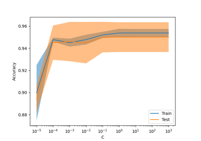

Release Highlights for scikit-learn 1.3

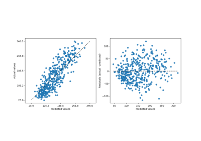

Release Highlights for scikit-learn 1.2

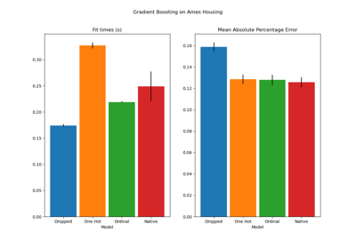

Categorical Feature Support in Gradient Boosting

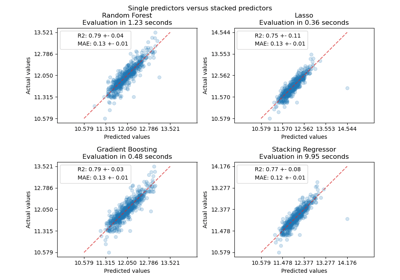

Combine predictors using stacking

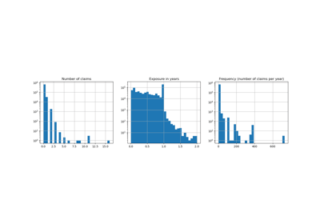

Poisson regression and non-normal loss

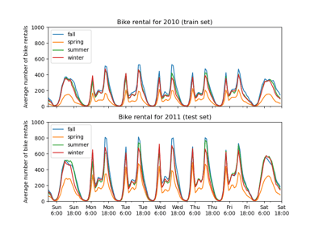

Partial Dependence and Individual Conditional Expectation Plots

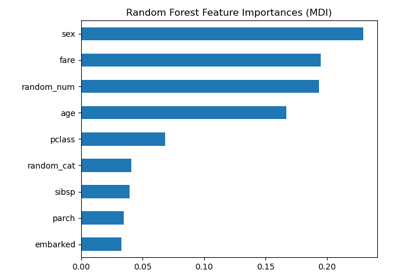

Permutation Importance vs Random Forest Feature Importance (MDI)

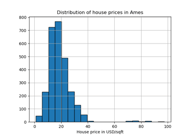

Evaluation of outlier detection estimators

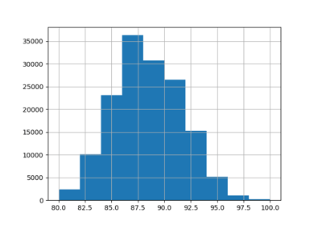

Comparing Target Encoder with Other Encoders

© 2007–2025 The scikit-learn developers  
Licensed under the 3-clause BSD License.  
https://scikit-learn.org/1.6/modules/generated/sklearn.preprocessing.OrdinalEncoder.html